# Effects of sediment on the survival of larval corals

Lillian J. Tuttle

9/25/2020

These datasets contain information from multiple articles (**Ref_name**) and studies/experiments (**Ref**) within those articles about the effects of SUSPENDED sediment on the **larval survival rate** of pre-settlement corals. I would like to explore the dose-response relationship between sediment ‘dose’ and the effect size, estimated here as the standardized mean difference between treatment and control, in terms of Hedges’ *d*:

- Hedges’ *d* is the standardized mean difference between the treatment and control groups (Hedges and Olkin 1985). Each study may have multiple Hedges’ *d* calculations, one for each treatment-control comparison at each time-point.
- ‘Dose’ can be quantified as sediment exposure concentration (mg/cm<sup>2</sup>/day), exposure duration (days), or as “cumulative exposure”, for which I multiply concentration and duration (mg/cm<sup>2</sup>).

Each study/experiment (Ref) may contain multiple sets of controls and treatments (due to using multiple species or sediment types, for instance). Thus, I have added two categorical vectors, ‘**Comparison**’ and ‘Control’, which group each set of control-treatment comparisons into a unique two-letter code, within which is one control (Control==“1”) and at least one treatment (Control==“0”). **Therefore, ‘Comparison’ is nested within ‘Ref’, which is further nested within ‘Ref_name’.**

# I. Larval Survival Rate

## A. Suspended Sediment

### 1. Plots

I calculated the standardized mean difference in terms of Hedges’ *d* and plot it here with respect to exposure concentration. I did this first for a Hedges’ *d* that I calculated before importing the data to R and again for a Hedges’ *d* that is calculated by the dosresmeta::covar.smd function.

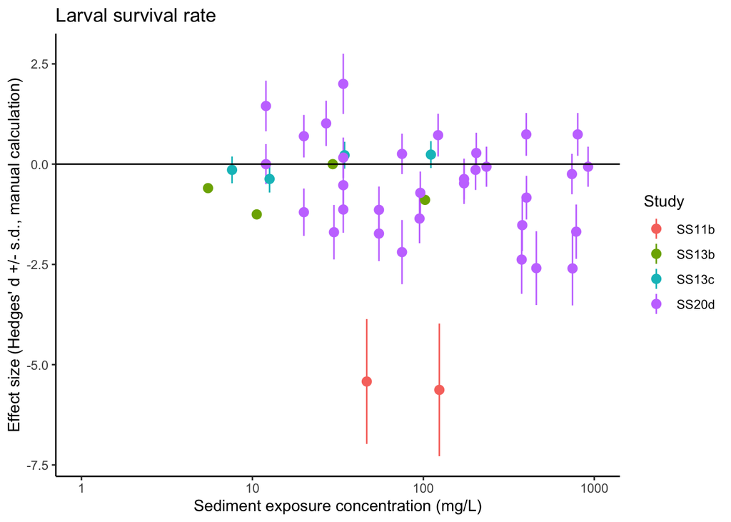

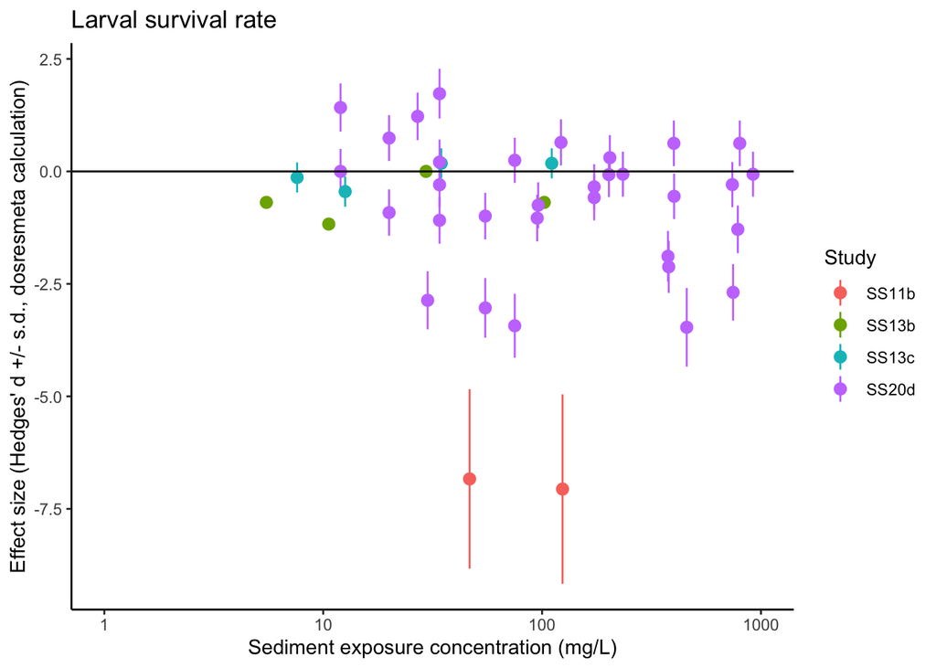

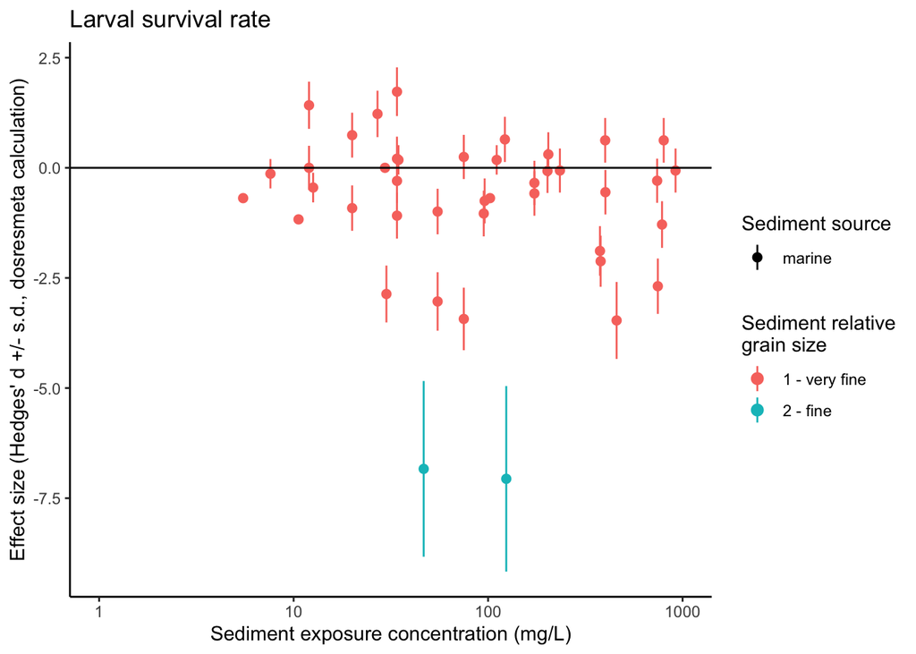

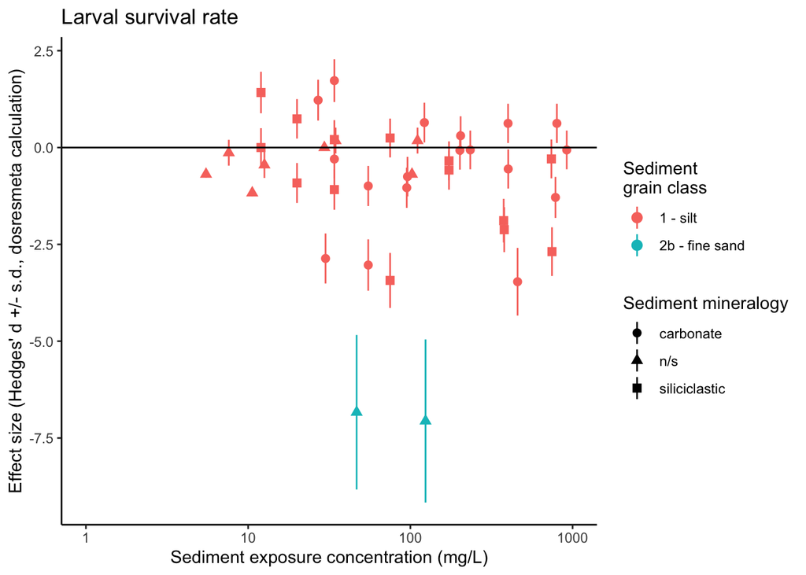

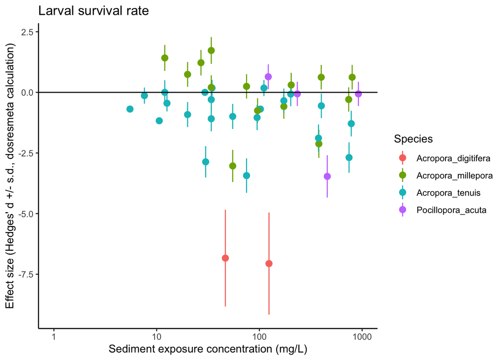

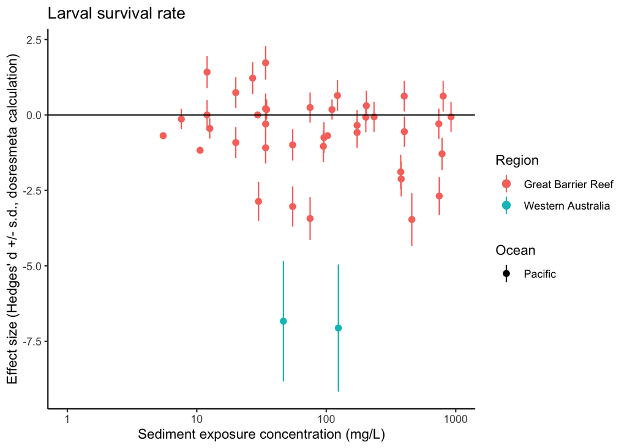

It is interesting that there is a difference between how I calculated Hedges’ *d* and how *dosresmeta* appears to calculate it. But in both cases, there does not appear to be an effect of sediment exposure on effect size, except for *Acropora digitifera*, for which there may a strong effect of sediment on effect size (though there are limited datapoints for this species). There is not a discernible effect of geography (ocean and region) because almost all of the data were from the Great Barrier Reef. I still need to investigate the effects of sediment type (source, origin, grain size).

### 2. Model Fitting

The following set of functions model fixed and random (nested) effects WITHOUT accounting for within-comparison (or within-study) correlations. The output for each is a univariate, random-effects meta-regression.

To account for within-comparison correlations in the mixmeta model, I replace the ‘S’ argument with a ‘control’ argument, which requires me to provide the covariance matrices, as done with the covar.smd function.

And now to compare relative fit of linear models…

```
##                      df      AIC
## mod_SS_larvalsurv_1d  5 174.9777
## mod_SS_larvalsurv_2d  8 184.5485
## mod_SS_larvalsurv_3d  8 181.8109
## mod_SS_larvalsurv_4d 11 179.1423
## mod_SS_larvalsurv_5d  5 183.6860
## mod_SS_larvalsurv_6d  8 185.4487
## mod_SS_larvalsurv_7d  8 189.7362
```

And now to evaluate residuals of models…

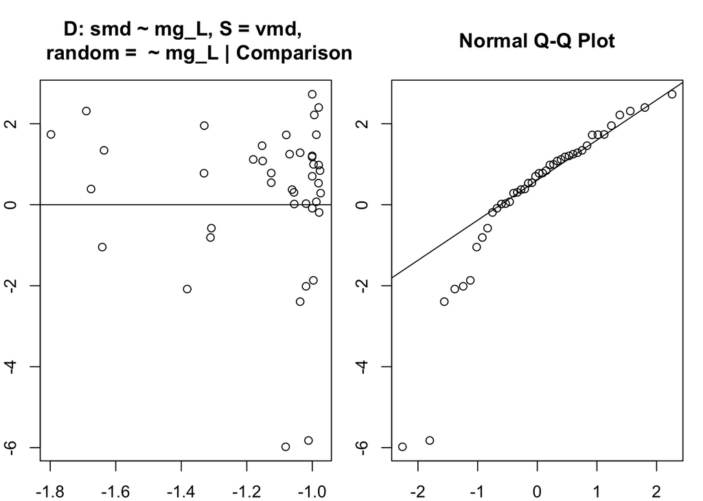

Patterns: 1. Residuals have relatively low magnitude of residuals (<abs(6)). 2. Slight outliers in negative residual land, but not extreme. 3. Might benefit from a log transformation of sediment exposure to even the horizontal spread of fitted values.

Now let’s check out a log, base 10 transformation of sediment exposure to see if it improves the residuals of the models.

To account for within-comparison correlations in the mixmeta model, I replace the ‘S’ argument with a ‘control’ argument, which requires me to provide the covariance matrices, as done with the covar.smd function.

And now to compare relative fit of linear models…

```
##                          df      AIC
## log_mod_SS_larvalsurv_1d  5 172.3236
## log_mod_SS_larvalsurv_2d  8 173.4599
## log_mod_SS_larvalsurv_3d  8 171.0664
## log_mod_SS_larvalsurv_4d 11 177.0665
## log_mod_SS_larvalsurv_5d  5 179.9218
## log_mod_SS_larvalsurv_6d  8 185.9218
## log_mod_SS_larvalsurv_7d  8 185.9218
```

And now to evaluate residuals of models…

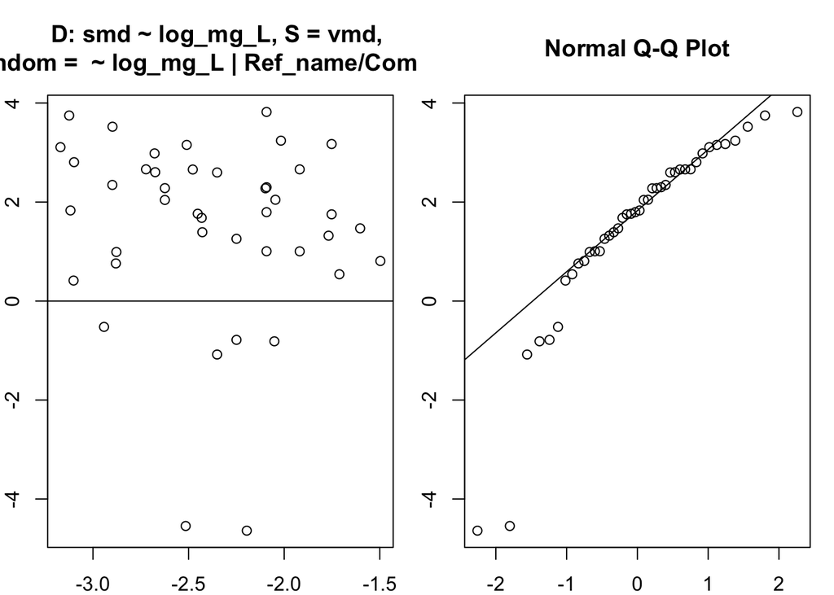

Patterns: 1. Looks great – still slight outliers in negative residual land, but not extreme, and now a more even horizontal spread of fitted values. No need for non-linear models.

### 3. Best-Fit Model Summary

#### MG/L IS PREDICTOR, Model using dosresmeta calculation of Hedges’ *d*

Now I will predict the effect size along the exposure range and plot with confidence intervals.

```
## Call:  mixmeta(formula = smd ~ log10_mg_L, S = vmd, data = ES_SS_larvalsurvival2,
##     random = ~log10_mg_L | Ref_name/Comparison, method = "ml")
##
## Univariate extended random-effects meta-regression
## Dimension: 1
## Estimation method: ML
##
## Fixed-effects coefficients
##              Estimate  Std. Error        z  Pr(>|z|)  95%ci.lb  95%ci.ub
## (Intercept)   -0.9401      1.0090  -0.9316    0.3515   -2.9177    1.0376
## log10_mg_L    -0.7524      0.5212  -1.4434    0.1489   -1.7740    0.2692
## ---
## Signif. codes:  0 '***' 0.001 '**' 0.01 '*' 0.05 '.' 0.1 ' ' 1
##
## Random-effects (co)variance components
##  Formula: ~log10_mg_L | Ref_name
##  Structure: General positive-definite
##              Std. Dev         Corr
## (Intercept)    1.4450  (Intercept)
## log10_mg_L     0.7585            1
##
##  Formula: ~log10_mg_L | Comparison
##  Structure: General positive-definite
##              Std. Dev         Corr
## (Intercept)    1.0611  (Intercept)
## log10_mg_L     0.4666      -0.8499
##
## Univariate Cochran Q-test for residual heterogeneity:
## Q = 147.8923 (df = 40), p-value = 0.0000
## I-square statistic = 73.0%
##
## 42 units, 1 outcome, 42 observations, 2 fixed and 6 random-effects parameters
##   logLik       AIC       BIC
## -77.5332  171.0664  184.9678
```

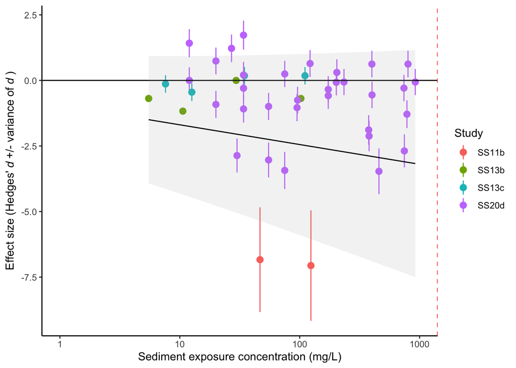

There is no significant relationship between exposure concentration to suspended sediment and the Hedges’ d effect size for larval survival (DRMA z = -1.4434, p = 0.1489).